# Prediction Summaries

Shannon E. Ellis

18 December 2017

# 1 Summary: recount2

A big picture summary of the data included in recount including:

- number of samples from each data source (GTEx, SRA, and TCGA)
- distribution of the number of samples per SRA project

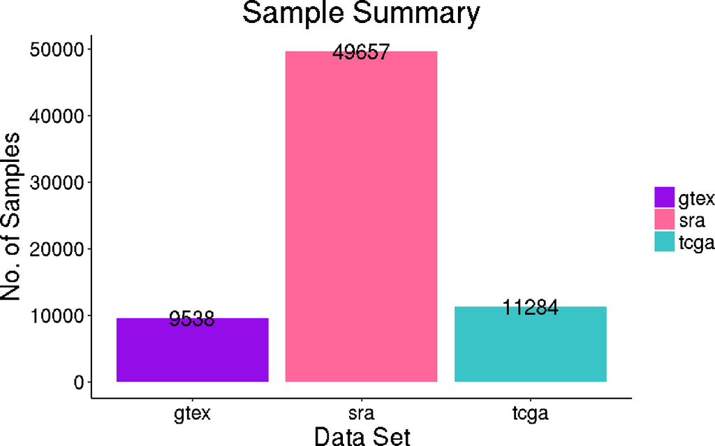

```
## [1] 2034
```

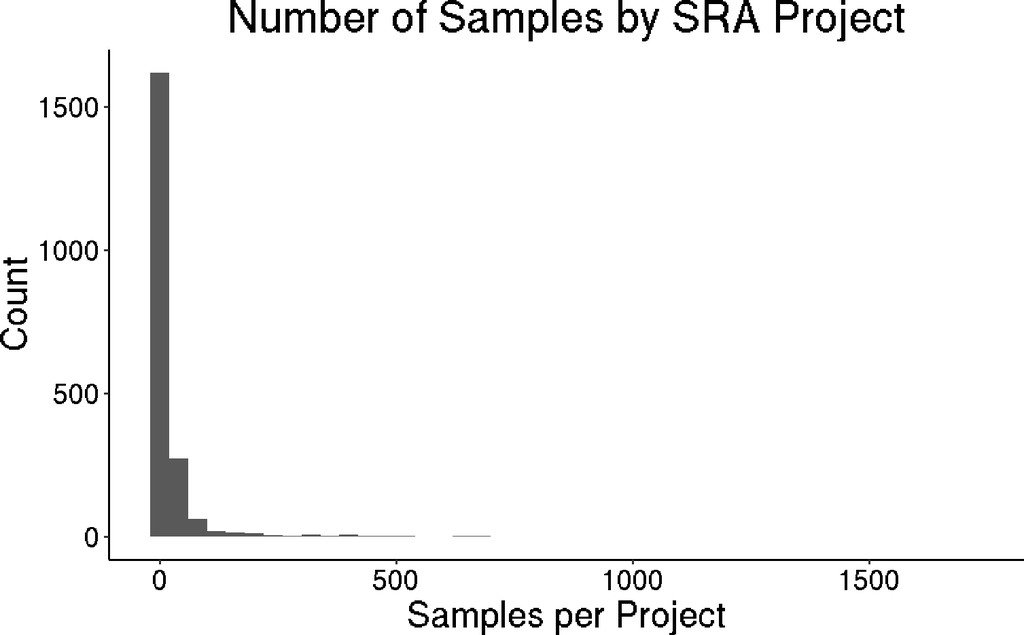

# 2 Sex

A summary of sex across recount including:

- overall breakdown of predicted sex across recount
- breakdown of predicted sex within SRA data
- Comparison of reported sex to predicted sex (frequency)
- Comparison of reported sex to predicted sex (proportion)
- specificity and sensitivity for sex
- Confusion Matrix for reported to prediced sex agreement (proportion)

predicted Count 1 female 35311 2 male 31461 3 Unassigned 3707

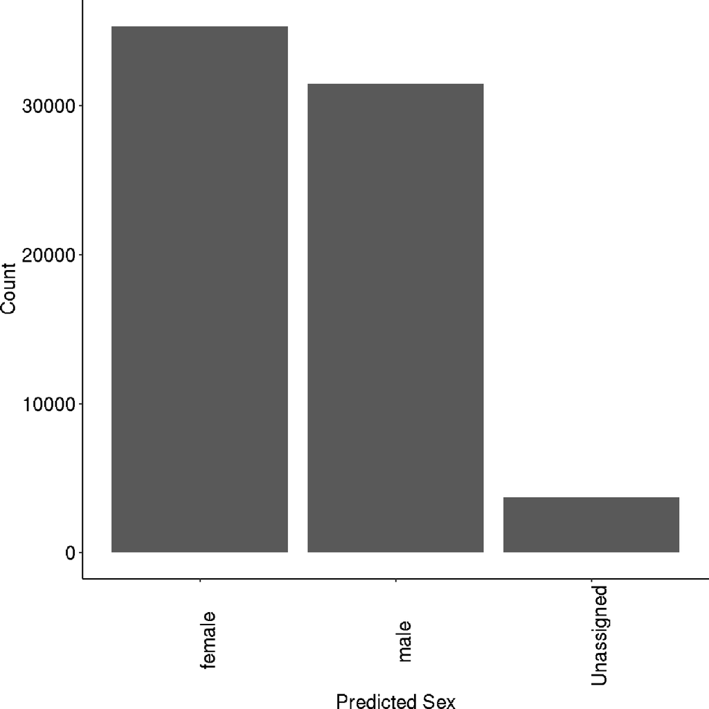

# A tibble: 3 x 2 predicted_sex Count 1 female 25862 2 male 20088 3 Unassigned 3707

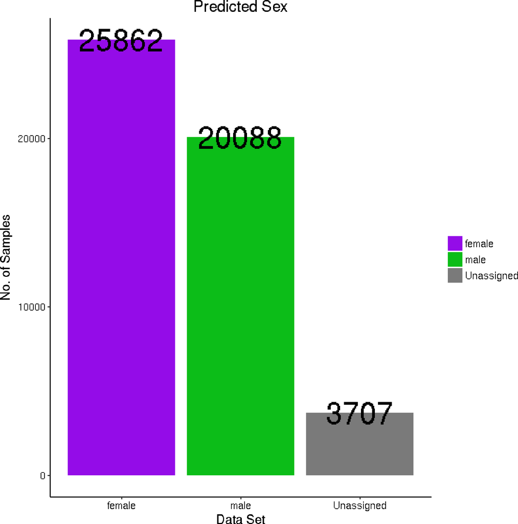

|  | Sensitivity | Specificity |
| --- | --- | --- |
| sex_female | 0.98 | 0.93 |
| sex_male | 0.96 | 0.95 |
| sex_Unassigned |  | 0.99 |

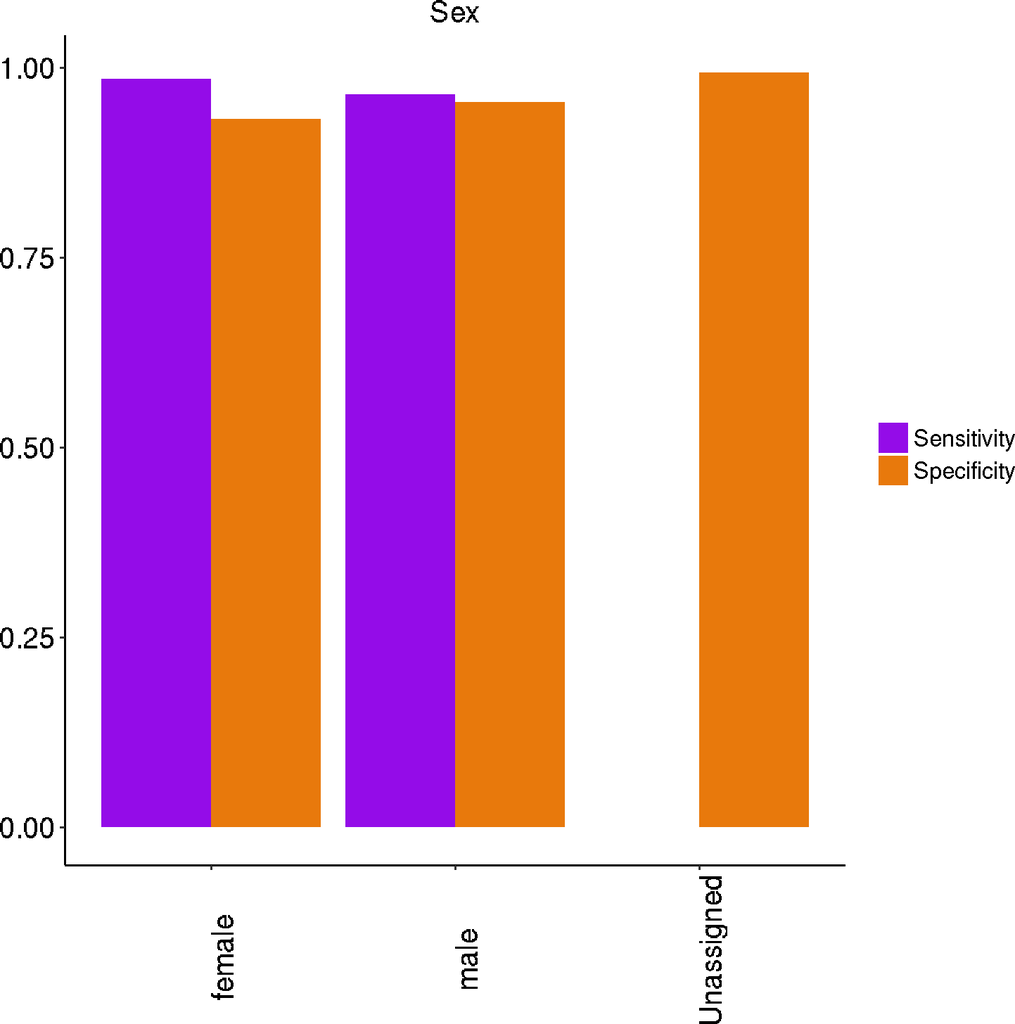

|  | 1 Male, 2 Female | asexual | DK | female | male | missing | mixture | pooled male and female | unknown |
| --- | --- | --- | --- | --- | --- | --- | --- | --- | --- |
| female | 4 | 3 | 8 | 11372 | 411 | 47 | 0 | 4 | 462 |
| male | 0 | 2 | 2 | 98 | 12418 | 41 | 6 | 29 | 395 |
| Unassigned | 0 | 0 | 2 | 78 | 46 | 0 | 0 | 0 | 49 |

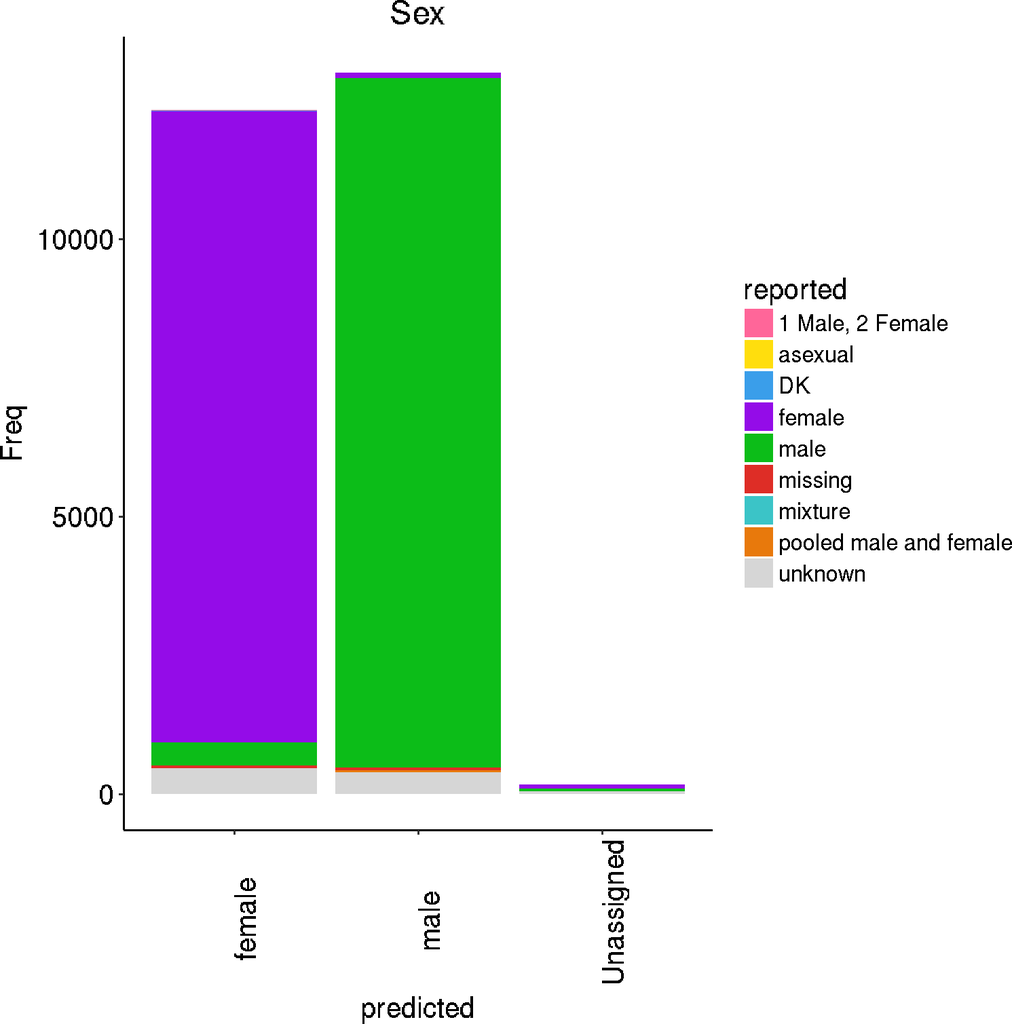

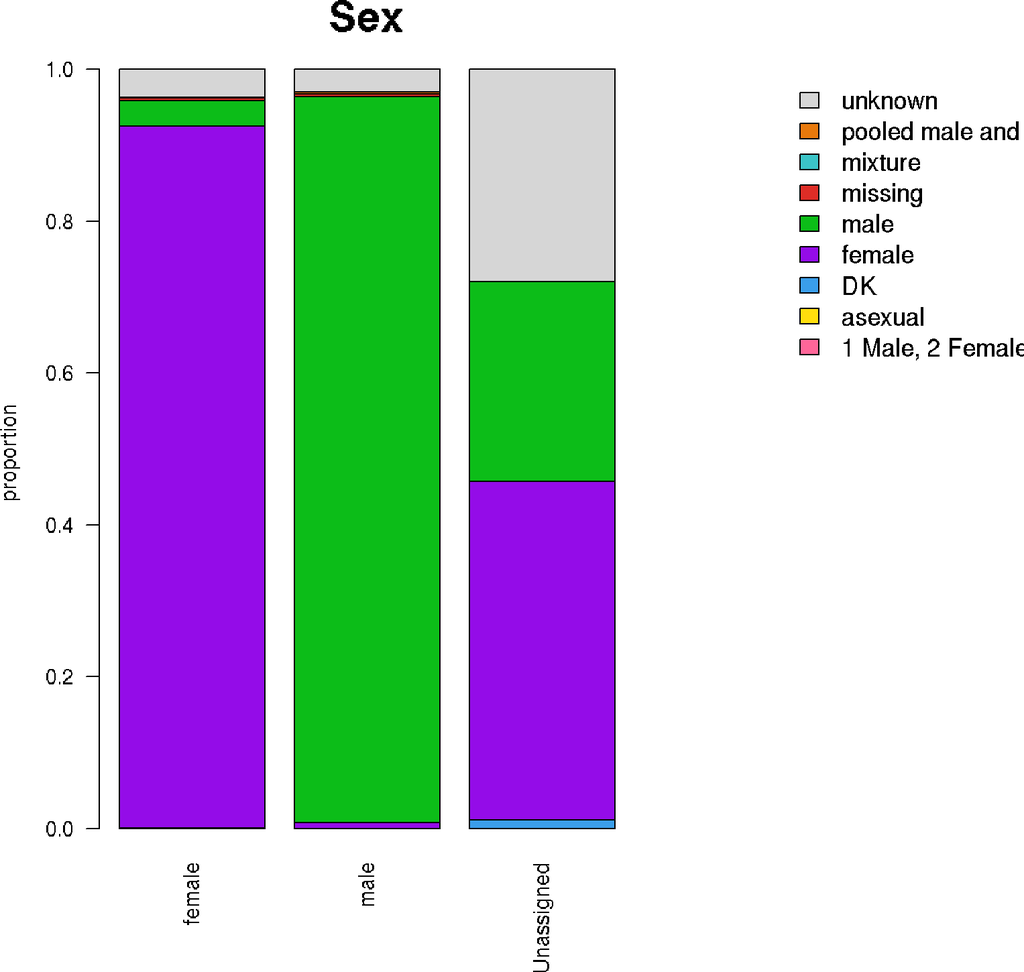

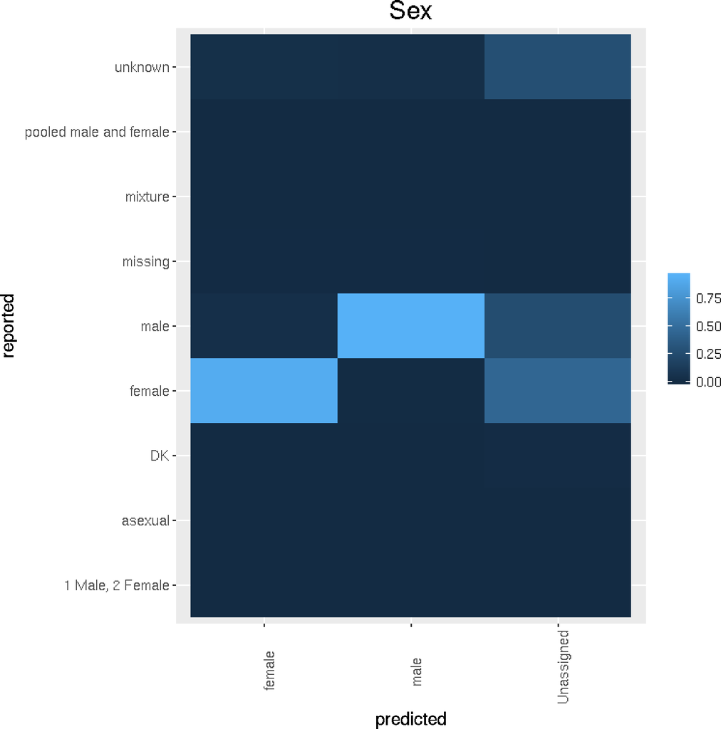

# 3 Tissue

A summary of tissue across recount including:

- overall breakdown of predicted tissue across recount
- overall breakdown of concordance between predicted and reported tissue
- specific breakdown of concordance between predicted and reported tissue (frequency)
- specific breakdown of concordance between predicted and reported tissue (proportion)
- specificity and sensitivity for tissue
- Confusion Matrix for reported to prediced tissue agreement (proportion)

predicted_tissue Count 1 Adipose Tissue 1619 2 Adrenal Gland 679 3 Bladder 3833 4 Blood 10377 5 Blood Vessel 1306 6 Brain 8637 7 Breast 2728 8 Cervix Uteri 116 9 Colon 2113 10 Esophagus 2410 11 Fallopian Tube 599 12 Heart 1640 13 Kidney 1587 14 Liver 1314 15 Lung 2998 16 Muscle 1436 17 Nerve 1175 18 Ovary 1115 19 Pancreas 601 20 Pituitary 998 21 Prostate 1767 22 Salivary Gland 713 23 Skin 7443 24 Small Intestine 2307 25 Spleen 788 26 Stomach 1435 27 Testis 506 28 Thyroid 1301 29 Unassigned 2617 30 Uterus 3470 31 Vagina 851

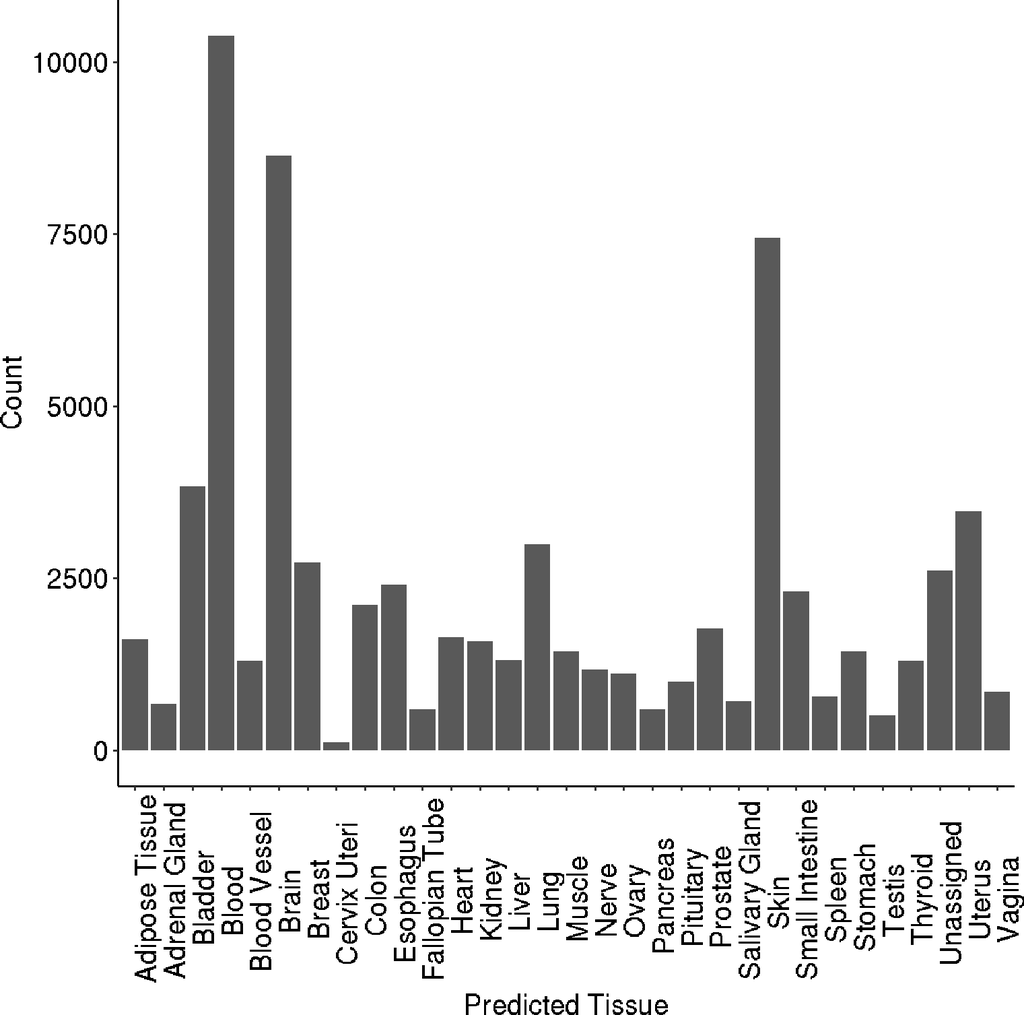

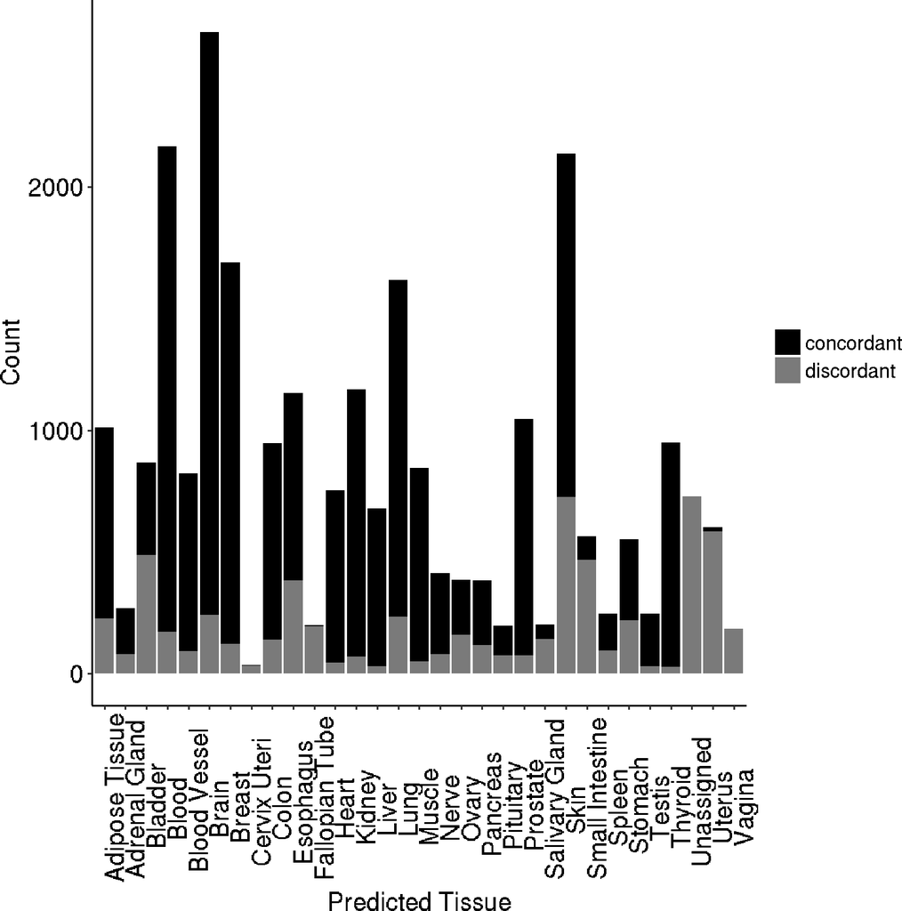

|  | Sensitivity | Specificity |
| --- | --- | --- |
| tissue_Adipose Tissue | 0.73 | 0.99 |
| tissue_Adrenal Gland | 0.98 | 1.00 |
| tissue_Bladder | 0.86 | 0.98 |
| tissue_Blood | 0.77 | 0.99 |
| tissue_Blood Vessel | 0.90 | 1.00 |
| tissue_Brain | 0.91 | 0.99 |
| tissue_Breast | 0.53 | 0.99 |
| tissue_Cervix Uteri | 0.27 | 1.00 |
| tissue_Colon | 0.65 | 0.99 |
| tissue_Esophagus | 0.97 | 0.98 |
| tissue_Fallopian Tube | 0.71 | 0.99 |
| tissue_Heart | 0.77 | 1.00 |
| tissue_Kidney | 0.64 | 1.00 |
| tissue_Liver | 0.84 | 1.00 |
| tissue_Lung | 0.74 | 0.99 |
| tissue_Muscle | 0.70 | 1.00 |
| tissue_Nerve | 0.99 | 1.00 |
| tissue_Ovary | 0.40 | 0.99 |
| tissue_Pancreas | 0.63 | 1.00 |
| tissue_Pituitary | 0.98 | 1.00 |
| tissue_Prostate | 0.86 | 1.00 |
| tissue_Salivary Gland | 0.83 | 0.99 |
| tissue_Skin | 0.92 | 0.97 |
| tissue_Small Intestine | 0.92 | 0.98 |
| tissue_Spleen | 0.79 | 1.00 |
| tissue_Stomach | 0.51 | 0.99 |
| tissue_Testis | 0.86 | 1.00 |
| tissue_Thyroid | 0.99 | 1.00 |
| tissue_Unassigned | 0.00 | 0.97 |
| tissue_Uterus | 0.19 | 0.98 |
| tissue_Vagina |  | 0.99 |

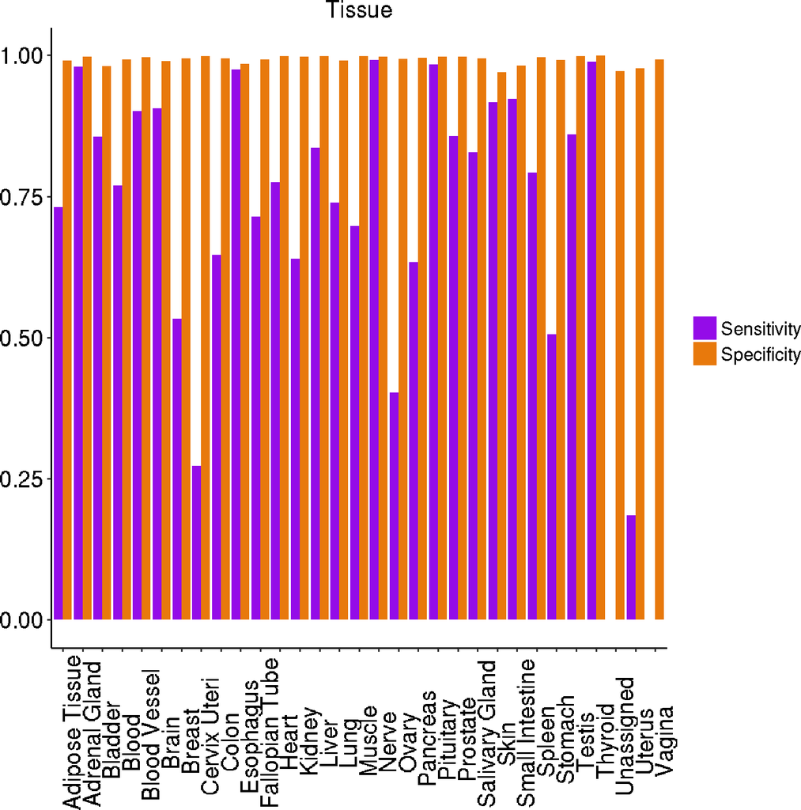

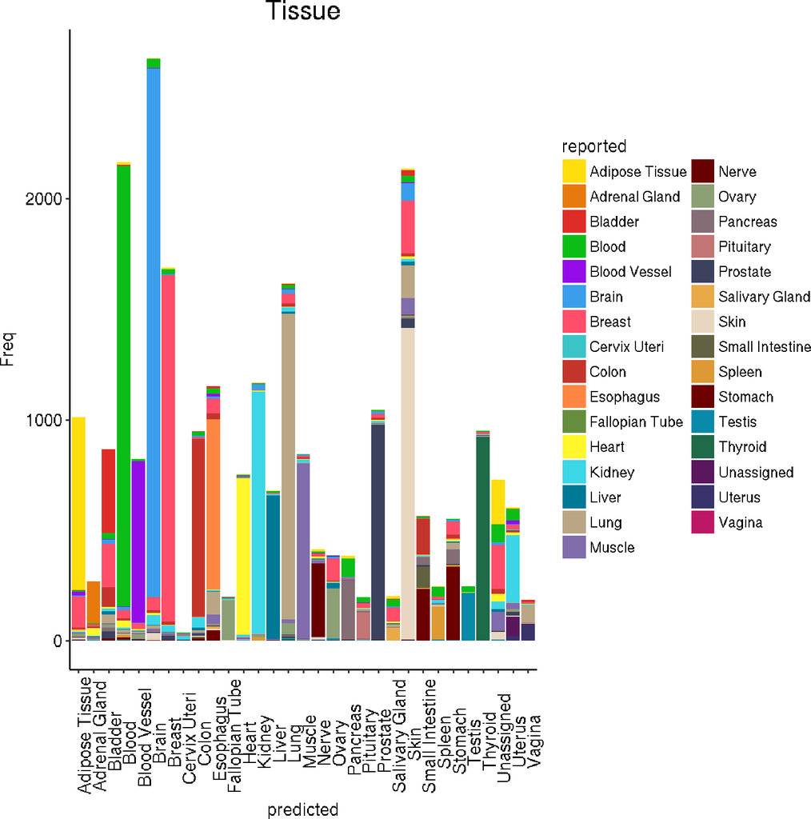

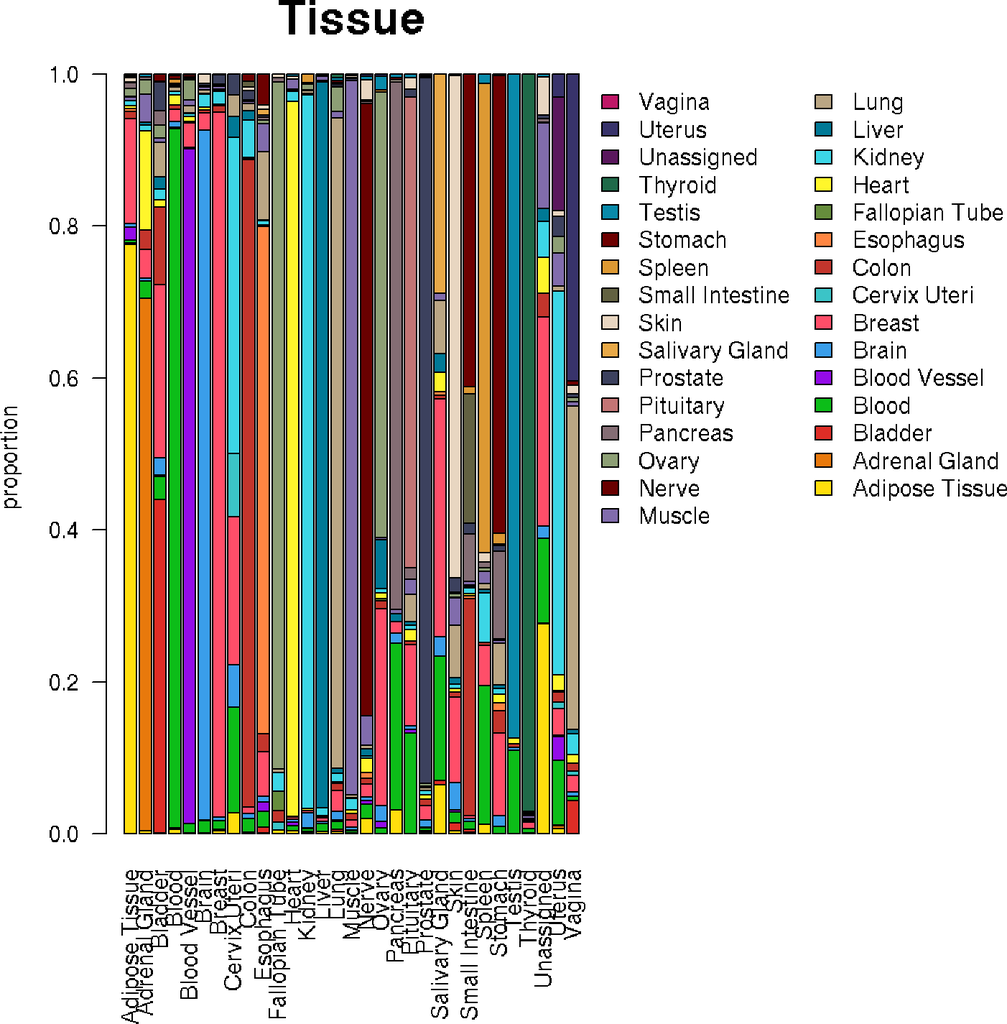

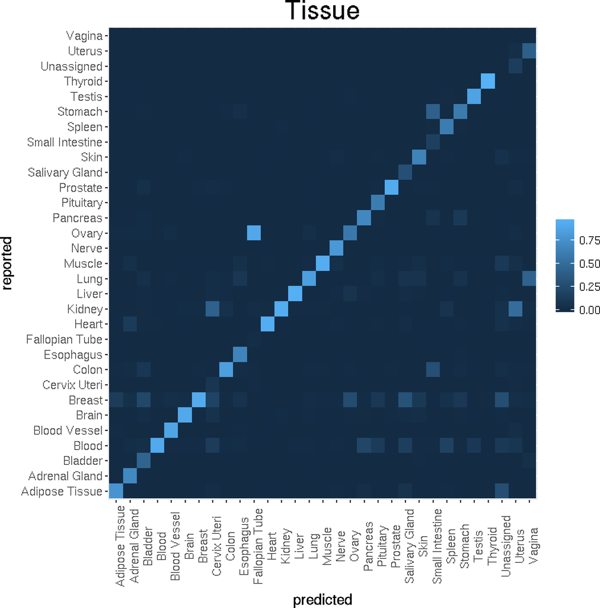

|  | Adipose Tissue | Adrenal Gland | Bladder | Blood | Blood Vessel | Bone | Bone Marrow | Brain | Breast | Central nervous system | Cervical | Cervix | Cervix Uteri | Colon | Distant Metastasis | Endometrial | Epithelium | Esophagus | Fallopian Tube | Head and Neck | Heart | Intestine | Kidney | Liver | Lung | Melanoma | Monocytes | Muscle | NA | … |
| --- | --- | --- | --- | --- | --- | --- | --- | --- | --- | --- | --- | --- | --- | --- | --- | --- | --- | --- | --- | --- | --- | --- | --- | --- | --- | --- | --- | --- | --- | --- |
| Adipose Tissue | 784 | 0 | 2 | 4 | 17 | 1 | 0 | 5 | 140 | 0 | 0 | 2 | 0 | 9 | 1 | 0 | 2 | 4 | 0 | 0 | 4 | 31 | 7 | 0 | 0 | 0 | 0 | 4 | 0 | … |
| Adrenal Gland | 1 | 188 | 0 | 6 | 0 | 0 | 0 | 1 | 10 | 0 | 0 | 9 | 0 | 7 | 2 | 0 | 2 | 0 | 0 | 0 | 35 | 8 | 2 | 1 | 0 | 1 | 0 | 10 | 0 | … |
| Bladder | 1 | 0 | 380 | 27 | 1 | 0 | 0 | 20 | 198 | 0 | 34 | 26 | 0 | 88 | 2 | 87 | 4 | 0 | 0 | 8 | 8 | 25 | 13 | 14 | 39 | 3 | 0 | 5 | 0 | … |
| Blood | 12 | 0 | 4 | 1995 | 4 | 79 | 122 | 15 | 36 | 0 | 0 | 5 | 0 | 11 | 8 | 4 | 24 | 0 | 0 | 3 | 30 | 21 | 9 | 1 | 13 | 3 | 77 | 3 | 0 | … |
| Blood Vessel | 0 | 0 | 1 | 10 | 730 | 4 | 0 | 2 | 26 | 0 | 0 | 30 | 0 | 0 | 0 | 6 | 6 | 2 | 0 | 0 | 5 | 39 | 3 | 1 | 8 | 0 | 0 | 6 | 0 | … |
| Brain | 1 | 0 | 1 | 42 | 3 | 11 | 0 | 2394 | 59 | 529 | 0 | 9 | 0 | 12 | 2 | 4 | 12 | 0 | 0 | 0 | 10 | 258 | 43 | 4 | 13 | 2 | 1 | 10 | 0 | … |
| Breast | 7 | 0 | 2 | 20 | 0 | 26 | 0 | 7 | 1568 | 0 | 4 | 7 | 0 | 14 | 0 | 6 | 88 | 0 | 0 | 1 | 3 | 79 | 30 | 3 | 2 | 1 | 1 | 6 | 0 | … |
| Cervix Uteri | 1 | 0 | 0 | 5 | 0 | 0 | 0 | 2 | 7 | 0 | 3 | 4 | 3 | 0 | 0 | 3 | 1 | 0 | 0 | 0 | 0 | 2 | 15 | 1 | 1 | 0 | 0 | 0 | 0 | … |
| Colon | 0 | 0 | 2 | 17 | 0 | 8 | 0 | 6 | 8 | 0 | 5 | 15 | 0 | 806 | 0 | 3 | 26 | 1 | 0 | 1 | 2 | 351 | 47 | 11 | 9 | 1 | 0 | 3 | 0 | … |
| Esophagus | 1 | 0 | 9 | 24 | 14 | 2 | 0 | 9 | 67 | 0 | 11 | 22 | 0 | 27 | 0 | 5 | 25 | 770 | 0 | 140 | 2 | 23 | 7 | 1 | 103 | 4 | 1 | 43 | 0 | … |
| Fallopian Tube | 1 | 0 | 0 | 0 | 0 | 0 | 0 | 0 | 0 | 0 | 10 | 0 | 2 | 3 | 0 | 272 | 0 | 0 | 5 | 0 | 0 | 3 | 5 | 0 | 1 | 0 | 0 | 0 | 0 | … |
| Heart | 3 | 0 | 0 | 5 | 3 | 3 | 0 | 3 | 2 | 0 | 0 | 5 | 0 | 1 | 0 | 0 | 7 | 0 | 0 | 0 | 709 | 29 | 10 | 1 | 1 | 1 | 0 | 10 | 0 | … |
| Kidney | 1 | 1 | 1 | 5 | 1 | 0 | 0 | 23 | 3 | 0 | 1 | 3 | 0 | 0 | 2 | 43 | 5 | 0 | 0 | 0 | 4 | 3 | 1096 | 2 | 5 | 1 | 0 | 1 | 0 | … |
| Liver | 2 | 0 | 0 | 7 | 0 | 1 | 0 | 2 | 3 | 0 | 0 | 4 | 0 | 1 | 0 | 0 | 4 | 0 | 0 | 0 | 1 | 40 | 7 | 649 | 1 | 2 | 0 | 4 | 0 | … |
| Lung | 4 | 0 | 5 | 17 | 3 | 9 | 0 | 18 | 44 | 0 | 9 | 46 | 0 | 16 | 8 | 54 | 39 | 0 | 0 | 1 | 3 | 24 | 18 | 11 | 1385 | 15 | 1 | 15 | 0 | … |
| Muscle | 1 | 0 | 0 | 2 | 1 | 0 | 0 | 3 | 8 | 0 | 0 | 4 | 0 | 7 | 0 | 0 | 4 | 0 | 0 | 32 | 4 | 24 | 13 | 1 | 3 | 0 | 0 | 794 | 0 | … |
| Nerve | 8 | 0 | 0 | 8 | 2 | 0 | 0 | 2 | 7 | 1 | 0 | 2 | 0 | 3 | 12 | 0 | 8 | 3 | 0 | 0 | 8 | 24 | 1 | 4 | 2 | 3 | 0 | 16 | 0 | … |
| Ovary | 0 | 0 | 0 | 3 | 3 | 1 | 1 | 8 | 100 | 0 | 0 | 3 | 0 | 4 | 0 | 2 | 6 | 0 | 1 | 0 | 3 | 103 | 2 | 25 | 0 | 1 | 0 | 1 | 0 | … |
| Pancreas | 12 | 0 | 0 | 84 | 0 | 0 | 0 | 5 | 6 | 0 | 0 | 4 | 0 | 0 | 0 | 0 | 2 | 0 | 0 | 0 | 0 | 37 | 0 | 4 | 0 | 0 | 0 | 2 | 0 | … |
| Pituitary | 0 | 0 | 0 | 26 | 1 | 1 | 0 | 1 | 21 | 0 | 0 | 4 | 0 | 1 | 1 | 2 | 9 | 0 | 0 | 0 | 3 | 37 | 1 | 1 | 7 | 0 | 0 | 4 | 0 | … |
| Prostate | 2 | 0 | 2 | 4 | 1 | 3 | 0 | 10 | 19 | 0 | 1 | 1 | 0 | 9 | 5 | 15 | 14 | 0 | 0 | 1 | 6 | 36 | 6 | 0 | 4 | 7 | 0 | 2 | 0 | … |
| Salivary Gland | 13 | 0 | 1 | 33 | 0 | 4 | 0 | 5 | 63 | 0 | 3 | 0 | 0 | 1 | 4 | 7 | 4 | 1 | 0 | 36 | 5 | 18 | 0 | 5 | 14 | 8 | 0 | 2 | 0 | … |
| Skin | 8 | 0 | 23 | 29 | 7 | 57 | 0 | 77 | 239 | 0 | 48 | 54 | 0 | 14 | 9 | 8 | 326 | 1 | 0 | 273 | 11 | 35 | 11 | 18 | 148 | 11 | 0 | 77 | 0 | … |
| Small Intestine | 1 | 0 | 2 | 6 | 0 | 0 | 0 | 2 | 2 | 0 | 3 | 310 | 0 | 161 | 0 | 3 | 6 | 2 | 0 | 0 | 2 | 237 | 4 | 1 | 1 | 2 | 0 | 3 | 0 | … |
| Spleen | 3 | 0 | 0 | 45 | 0 | 9 | 2 | 0 | 13 | 0 | 1 | 5 | 0 | 1 | 3 | 0 | 4 | 0 | 0 | 0 | 0 | 10 | 16 | 1 | 2 | 0 | 0 | 4 | 0 | … |
| Stomach | 0 | 0 | 0 | 5 | 0 | 9 | 0 | 8 | 60 | 0 | 24 | 40 | 0 | 16 | 0 | 11 | 59 | 6 | 0 | 0 | 6 | 48 | 4 | 3 | 30 | 0 | 0 | 2 | 0 | … |
| Testis | 0 | 0 | 0 | 27 | 0 | 0 | 0 | 1 | 0 | 0 | 0 | 0 | 0 | 1 | 0 | 0 | 5 | 0 | 0 | 0 | 2 | 4 | 0 | 0 | 0 | 0 | 0 | 0 | 0 | … |
| Thyroid | 1 | 0 | 0 | 5 | 0 | 1 | 0 | 0 | 8 | 0 | 0 | 2 | 0 | 2 | 0 | 2 | 17 | 0 | 0 | 0 | 0 | 23 | 1 | 0 | 2 | 0 | 0 | 3 | 0 | … |
| Unassigned | 201 | 1 | 0 | 81 | 0 | 1 | 0 | 12 | 200 | 0 | 0 | 43 | 0 | 23 | 0 | 0 | 63 | 0 | 0 | 0 | 34 | 31 | 35 | 12 | 0 | 11 | 3 | 82 | 0 | … |
| Uterus | 4 | 2 | 1 | 51 | 19 | 8 | 0 | 1 | 21 | 0 | 3 | 47 | 5 | 8 | 7 | 38 | 42 | 0 | 1 | 1 | 13 | 68 | 304 | 0 | 4 | 5 | 0 | 26 | 0 | … |
| Vagina | 0 | 0 | 8 | 1 | 0 | 1 | 0 | 1 | 4 | 1 | 149 | 6 | 1 | 2 | 2 | 1 | 4 | 0 | 0 | 51 | 2 | 13 | 5 | 1 | 78 | 1 | 0 | 1 | 0 | … |

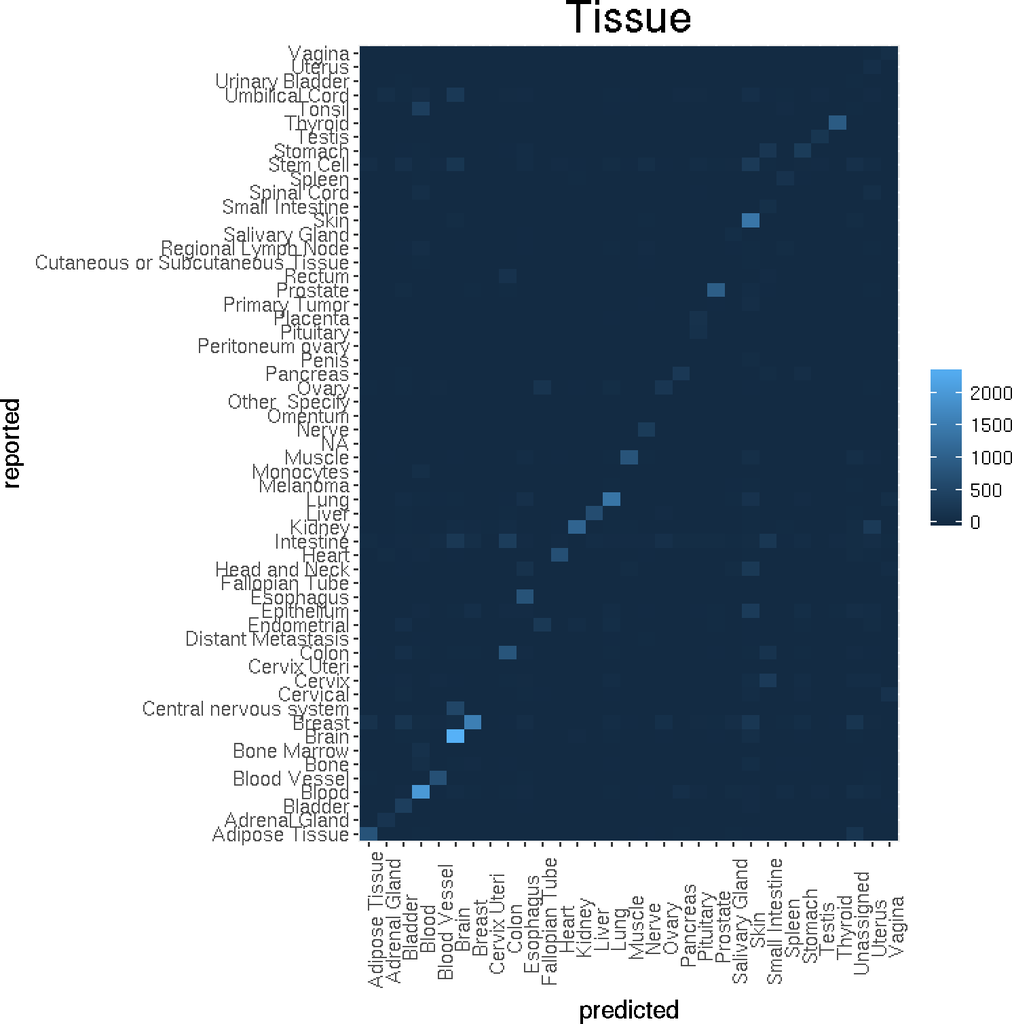

# 4 Sequencing Strategy

A summary of sequencing strategy across recount including:

- overall breakdown of predicted sequencing strategy across recount
- breakdown of concordance between predicted and reported sequencing strategy (frequency)
- breakdown of concordance between predicted and reported sequencing strategy (proportion)
- specificity and sensitivity for sequencing strategy
- confusion Matrix for reported to prediced sequencing strategy agreement (proportion)

predicted Count 1 PAIRED 44621 2 SINGLE 25306 3 Unassigned 552

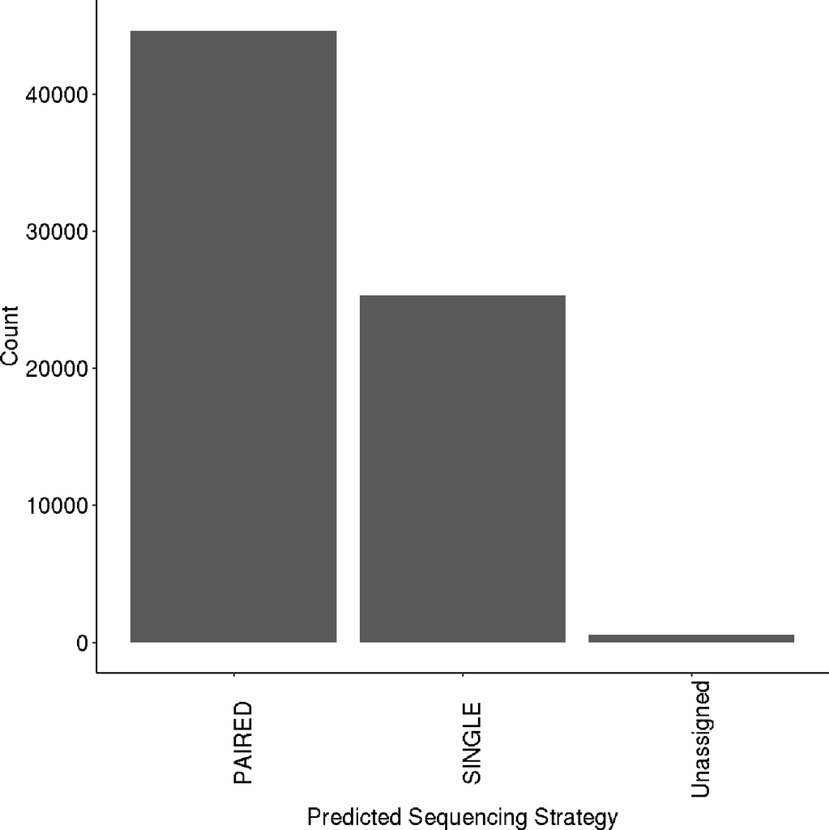

|  | Sensitivity | Specificity |
| --- | --- | --- |
| sequencingstrategy_PAIRED | 0.91 | 0.97 |
| sequencingstrategy_SINGLE | 0.95 | 0.92 |
| sequencingstrategy_Unassigned |  | 0.99 |

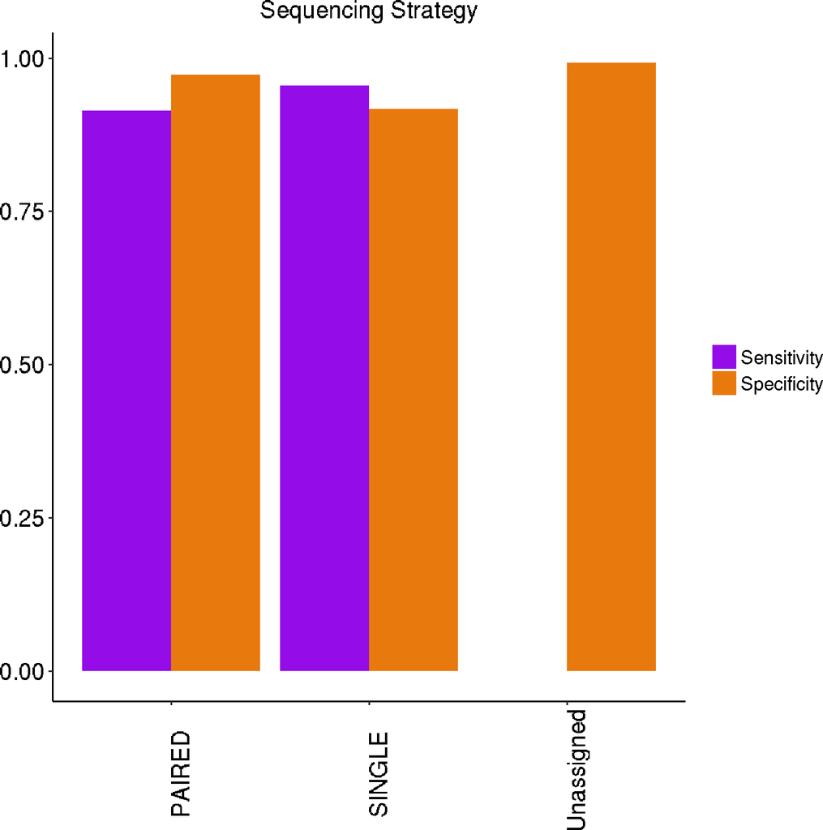

|  | PAIRED | SINGLE |
| --- | --- | --- |
| PAIRED | 44017 | 604 |
| SINGLE | 3983 | 21323 |
| Unassigned | 148 | 404 |

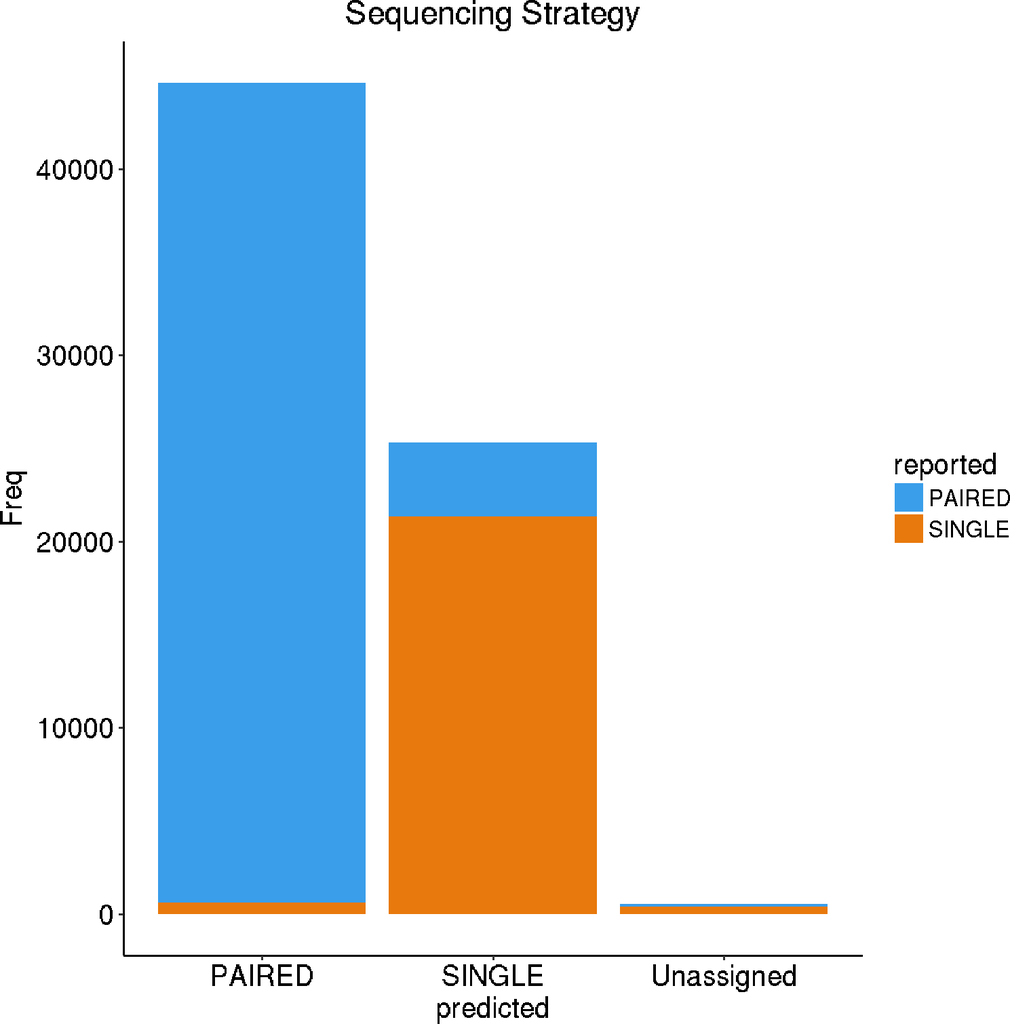

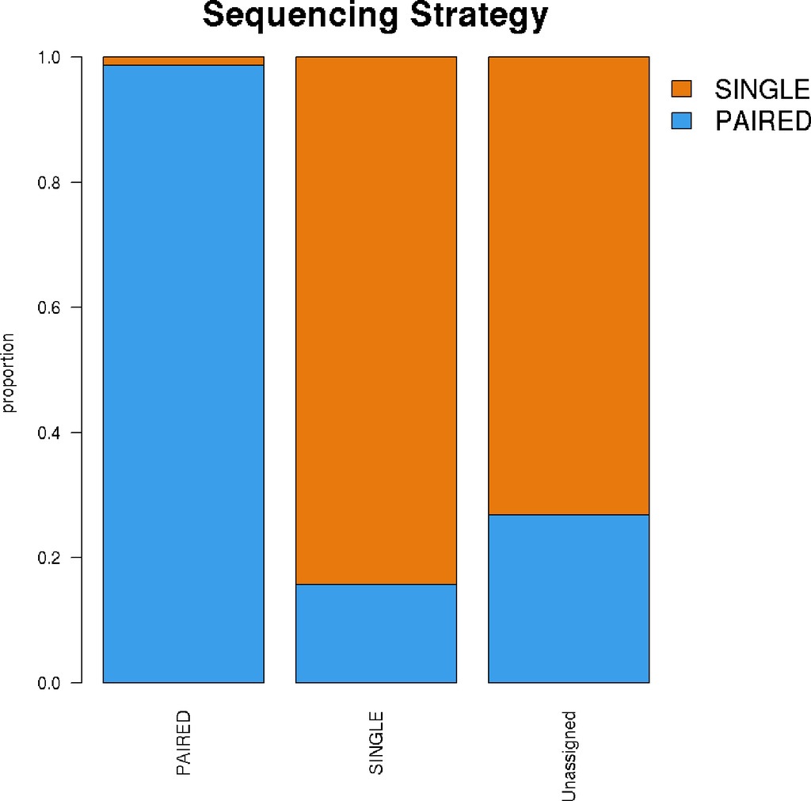

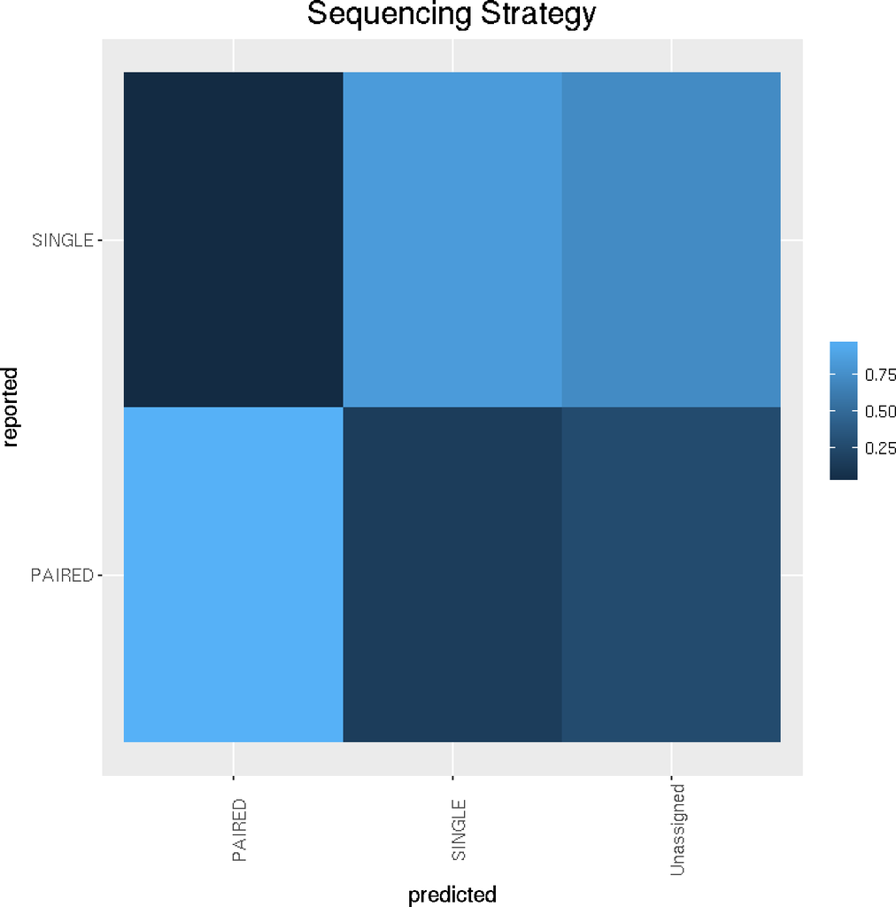

# 5 Sample Source

A summary of sample source across recount including:

- overall breakdown of predicted sample source across recount
- breakdown of concordance between predicted and reported sample source (frequency)
- breakdown of concordance between predicted and reported sample source(proportion)
- specificity and sensitivity for sample source
- confusion Matrix for reported to prediced sample source agreement (proportion)

predicted Count 1 cell_line 17369 2 tissue 52288 3 Unassigned 822

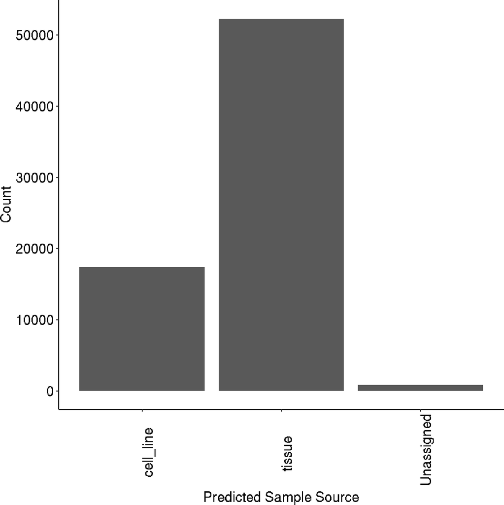

|  | Sensitivity | Specificity |
| --- | --- | --- |
| samplesource_cell_line | 0.89 | 0.95 |
| samplesource_tissue | 0.95 | 0.90 |
| samplesource_Unassigned |  | 1.00 |

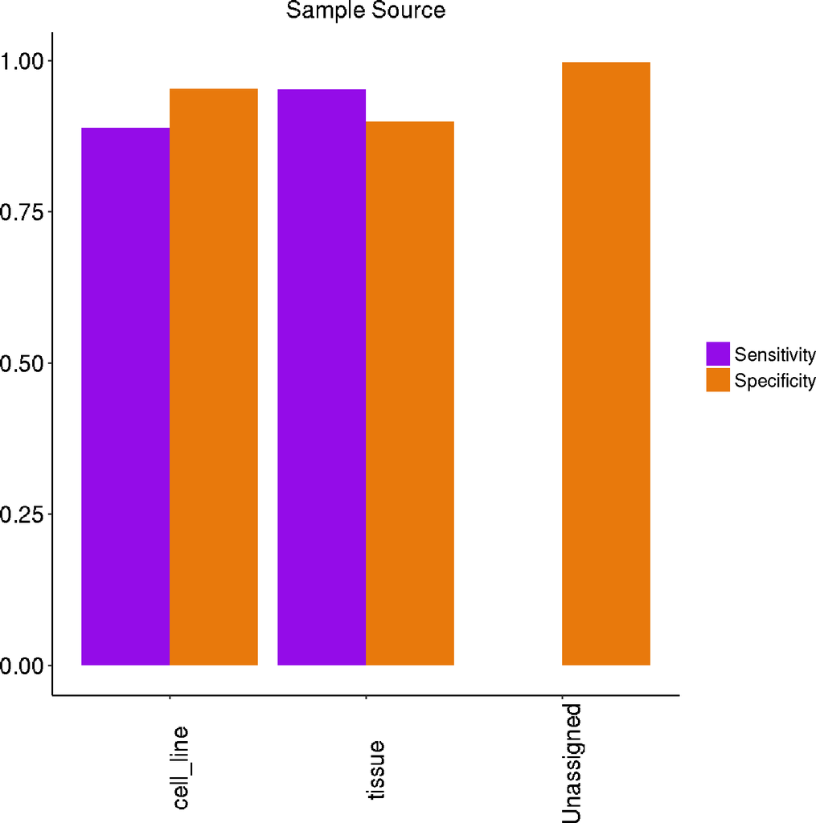

|  | cell_line | tissue |
| --- | --- | --- |
| cell_line | 8570 | 1549 |
| tissue | 976 | 31360 |
| Unassigned | 98 | 26 |

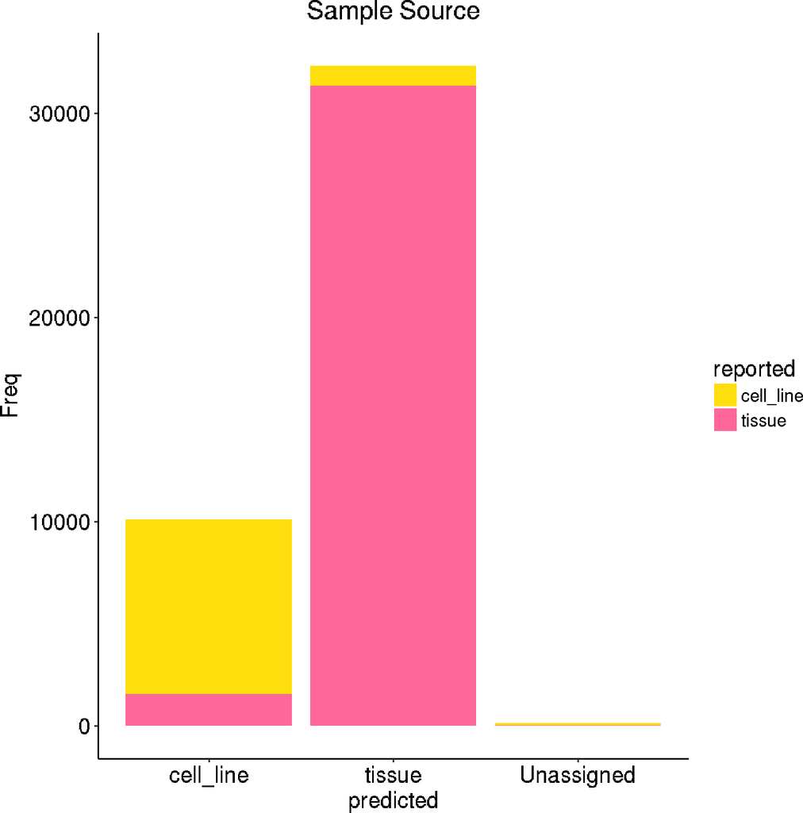

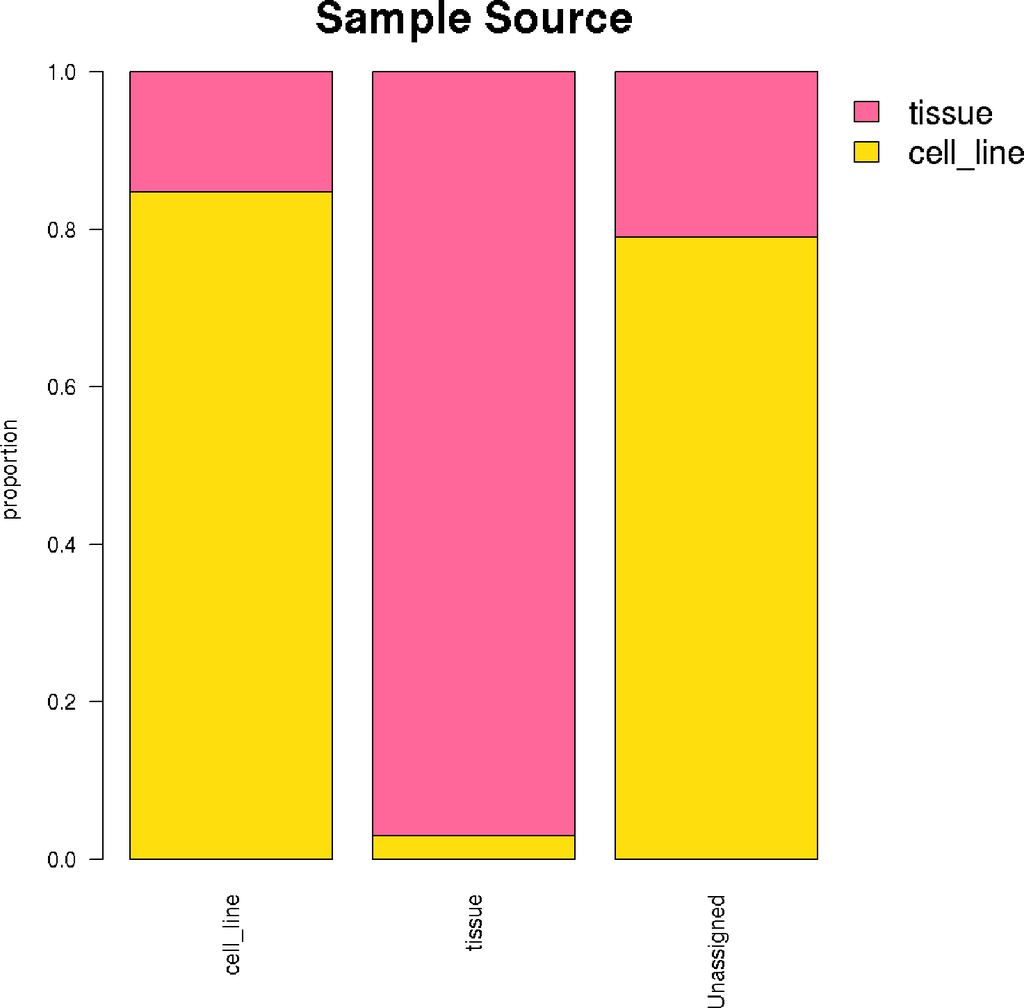

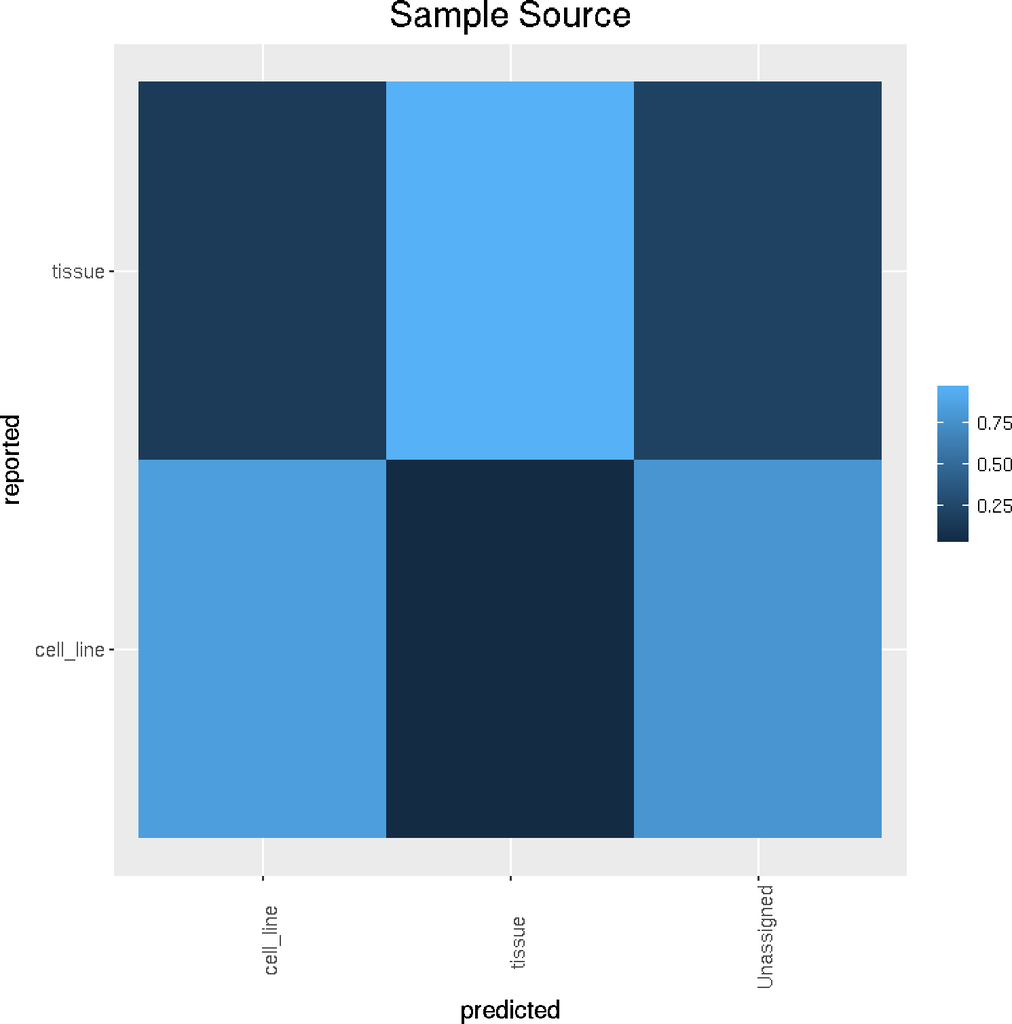

# 6 Vignette information

```r
## Time spent creating this report:
diff(c(startTime, Sys.time()))
```

```
## Time difference of 6.199357 mins
```

```r
## Date this report was generated
message(Sys.time())
```

```
## 2017-12-18 15:01:51
```

```r
## Reproducibility info
options(width = 120)
```

```
##  setting  value
##  version  R version 3.4.0 Patched (2017-05-16 r72696)
##  system   x86_64, linux-gnu
##  ui       X11
##  language (EN)
##  collate  en_US.UTF-8
##  tz       <NA>
##  date     2017-12-18
```

```
## Packages --------------------------------------------------------------------------------------------------------------
```

[output not shown]

[output cut: 47 more lines]

[output not shown]

Code for creating the vignette

```r
## Create the vignette
library('rmarkdown')
system.time(render('/dcl01/leek/data/sellis/barcoding/phenotype_vignettes/Summaries.Rmd', 'BiocStyle::html_document'))

## Extract the R code
library('knitr')
knit('/dcl01/leek/data/sellis/barcoding/phenotype_vignettes/Summaries.Rmd', tangle = TRUE)
```